# Reproducible Research: Peer Assessment 1

## Loading and preprocessing the data

The following code chunk use `fread()` function function from `data.table` package to read the activity data. Then the **date** column is explicitly converted to `date` format using `as.Date()` function.

```r
library(data.table)
activity_data = fread("activity.csv")
activity_data$date = as.Date(activity_data$date, "%Y-%m-%d")
```

## What is mean total number of steps taken per day?

As we can see there are a lot of NAs in the column **steps**, so we have to get a data table without NA to start with. Then we sum over the steps for one day.

```r
activity_data_noNA = activity_data[complete.cases(activity_data),]
steps_per_day = activity_data_noNA[,lapply(.SD, sum), by="date"]
```

Then the time to make a histogram about the total number of steps taken each day:

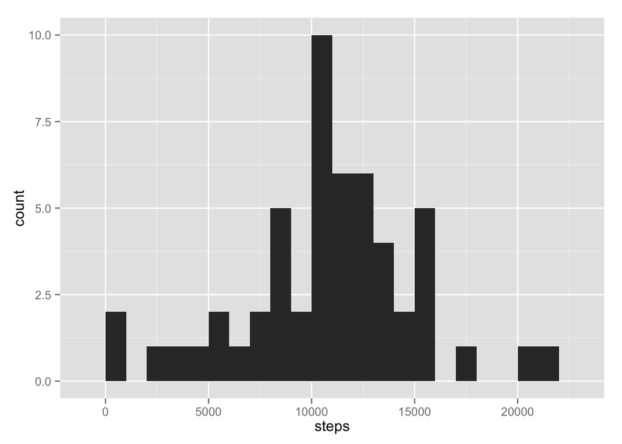

```r
library(ggplot2)
qplot(steps, data=steps_per_day, geom="histogram",binwidth=1000)
```

Now we calculate the mean and median

```r
steps_mean = mean(steps_per_day$steps)
steps_meadian = median(steps_per_day$steps)
print(paste("Mean: ", steps_mean,
            ", median: ", steps_meadian))
```

```
## [1] "Mean:  10766.1886792453 , median:  10765"
```

## What is the average daily activity pattern?

Now we find the mean number of steps taken by the intervals across all the dates. Then make a time series plot to show the tendency of daily activity changing with time intervals.

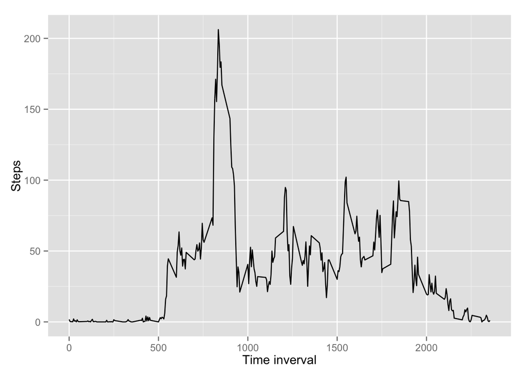

```r
steps_per_interval=activity_data_noNA[,mean(steps),by=interval]
ggplot(steps_per_interval, aes(interval, V1)) + geom_line() +
  xlab("Time inverval") + ylab("Steps")
```

The maximum of the average steps across all days happened at interval can be found by

```r
max_interval = steps_per_interval[, .SD[which.max(V1)]]
print(paste("Interval with max steps: ",max_interval$interval))
```

```
## [1] "Interval with max steps:  835"
```

## Imputing missing values

First we need to find how many rows contain missing value. Function `complete.case` finds out which row is free of NAs, so we take its inverse to find the rows having NA.

```r
rows_noNA = complete.cases(activity_data)
rows_haveNA = !rows_noNA
print(paste("total number of rows with NA: ", sum(rows_haveNA)))
```

```
## [1] "total number of rows with NA:  2304"
```

Now we replace the NAs in steps of a specific interval by the average of that interval across all the days:

```r
activity_data_complete=merge(activity_data, steps_per_interval, by="interval")
activity_data_complete=activity_data_complete[order(date, interval),]
na_idx = is.na(activity_data_complete$steps)
activity_data_complete$steps[na_idx] = activity_data_complete$V1[na_idx]
```

`activity_data_complete` is the new dataset without NA. The reason for eliminating NAs in this way is that, the steps are all NAs for several days, so replace NA in certain interval by the day average is not possiable.

Now we make a histogram of total number of steps taken per day for the new dataset `activity_data_complete`, to see how it differs from the first one.

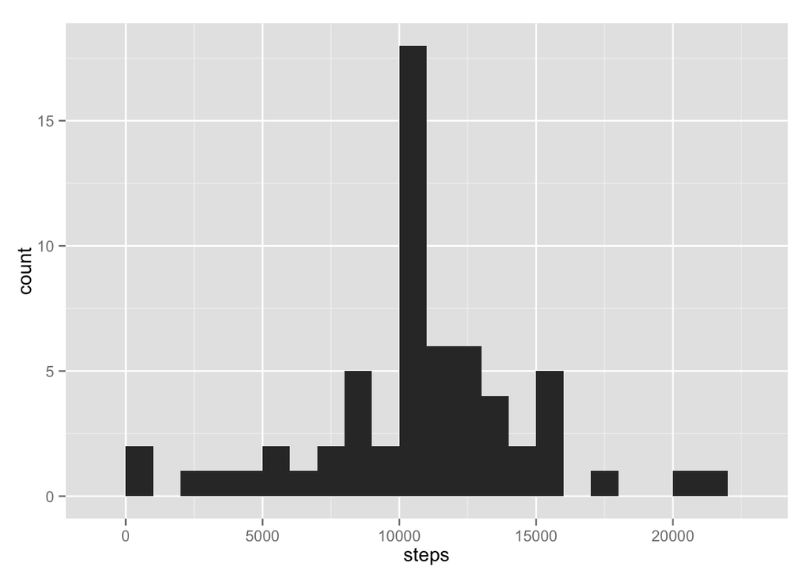

```r
steps_per_day_new = activity_data_complete[,lapply(.SD, sum), by="date"]
qplot(steps, data=steps_per_day_new, geom="histogram", binwidth=1000)
```

```r
steps_mean_new = mean(steps_per_day_new$steps)
steps_median_new = median(steps_per_day_new$steps)
print(paste("New dataset has mean: ", steps_mean_new,
            ", median: ", steps_median_new))
```

```
## [1] "New dataset has mean:  10766.1886792453 , median:  10766.1886792453"
```

If we imputes missing data in this way, we would push the data manually to these means.

## Are there differences in activity patterns between weekdays and weekends?

To see the activity pattern betwwen weekday and weekend, we first need to create a new column to categorize the data by weekday and weekend, then get the mean value at each time interval

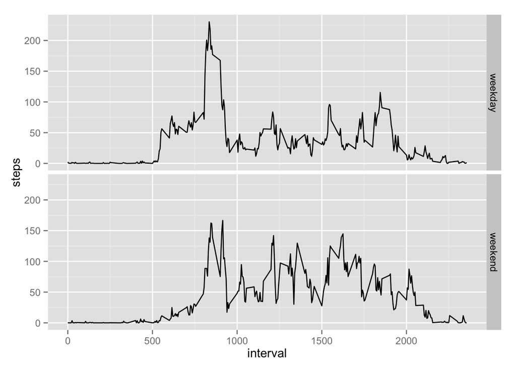

```r
activity_data_complete$date =
    as.Date(activity_data_complete$date, format="%Y-%m-%d")
activity_data_complete$weekday = weekdays(activity_data_complete$date)
activity_data_complete$weekday=
    gsub("Saturday|Sunday", "weekend",activity_data_complete$weekday)
activity_data_complete$weekday=
    gsub("Monday|Tuesday|Wednesday|Thursday|Friday",
         "weekday",activity_data_complete$weekday)
activity_data_complete$weekday = as.factor(activity_data_complete$weekday)
steps_per_interval_new = activity_data_complete[, lapply(.SD, mean),
                                            .SDcol = "steps",
                                            by = c("interval","weekday")]
ggplot(steps_per_interval_new,
       aes(x = interval, y = steps)) +
       geom_line() + facet_grid(weekday~.)
```